# Finansiering 2026

HA.jur. · Finansiering del 2

Vi arbejder med renter, obligationer, dansk realkredit og finansielle kriser. I regneeksemplerne følger vi, hvem der betaler, hvem der får pengene, og hvem der bærer risikoen.

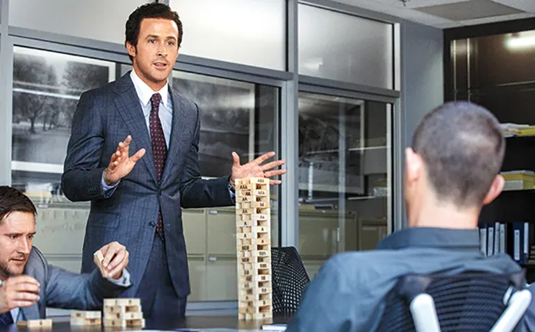

19. oktober – 26. november 2026 · 6 uger · 12 undervisningsmoduler

Hent lektionsnoterne

Se lektionsplanen

## Kursusinformation

### Kontakt

**Forelæser:** Niklas Lehmann Jensen  
**Mail:** nlj@econ.au.dk · niklas@scanrate.dk  
**Træffetid:** Skriv en mail, hvis du har spørgsmål.  
**Kursusrum:** Brightspace og denne side.

**Niveau:** Bachelor, HA.jur. Grundlæggende matematik og økonomi er en fordel.

### Vi mødes to gange om ugen

**Første gang: mandag 19. oktober kl. 16.00–18.00**, lokale **1830-211 Auditorium**.

**Tirsdage kl. 08.00–10.00** fra 20. oktober, lokale **1810-211 Auditorium**.

**Torsdage kl. 14.00–16.00** fra 29. oktober, lokale **1830-211 Auditorium**.

Første uge mødes vi mandag og tirsdag. Fra uge 44 mødes vi tirsdag og torsdag. Sidste gang er torsdag den **26. november 2026**.

Eventuelle ændringer fremgår af Brightspace.

## Kursusintroduktion i slideformat

[interactive chart not shown]

Åbn introduktionen i fuld skærm · Hent introduktionen som PDF

## Lektionsplan · efterår 2026

Vi begynder med introduktionen og kapitel 1 og følger derefter bogens kapitler i rækkefølge. Modul 11 er buffer. I modul 12 gennemgår vi en tidligere eksamen.

| Modul | Uge | Dato | Tid | Lokale | Indhold | Læsning |
| --- | --- | --- | --- | --- | --- | --- |
| 1 | 43 | Mandag 19/10 | 16.00–18.00 | 1830-211 Auditorium | Introduktion + Rentedannelsen | Kapitel 1 |
| 2 | 43 | Tirsdag 20/10 | 08.00–10.00 | 1810-211 Auditorium | Obligationsmarkedet | Kapitel 2 |
| 3 | 44 | Tirsdag 27/10 | 08.00–10.00 | 1810-211 Auditorium | Rentestrukturen | Kapitel 3 |
| 4 | 44 | Torsdag 29/10 | 14.00–16.00 | 1830-211 Auditorium | Risikomål | Kapitel 4 |
| 5 | 45 | Tirsdag 03/11 | 08.00–10.00 | 1810-211 Auditorium | Dansk realkredit | Kapitel 5 |
| 6 | 45 | Torsdag 05/11 | 14.00–16.00 | 1830-211 Auditorium | Modellering af konverteringsadfærd | Kapitel 6 |
| 7 | 46 | Tirsdag 10/11 | 08.00–10.00 | 1810-211 Auditorium | Prisfastsættelse og nøgletal | Kapitel 7 |
| 8 | 46 | Torsdag 12/11 | 14.00–16.00 | 1830-211 Auditorium | Obligationsafkast | Kapitel 8 |
| 9 | 47 | Tirsdag 17/11 | 08.00–10.00 | 1810-211 Auditorium | Finanskrisen | Kapitel 9 |
| 10 | 47 | Torsdag 19/11 | 14.00–16.00 | 1830-211 Auditorium | Pengeinstitutternes risikostyring | Kapitel 10 |
| 11 | 48 | Tirsdag 24/11 | 08.00–10.00 | 1810-211 Auditorium | Buffer og opsamling | Efter behov |
| 12 | 48 | Torsdag 26/11 | 14.00–16.00 | 1830-211 Auditorium | Tidligere eksamen som eksempel | Tidligere eksamensopgave |

## Slides til de ti kapitler

Åbn slides i browseren eller hent dem som PDF. Brug piletasterne til at skifte slide og Esc til at se hele kapitlet.

Kapitel 01

### Rentedannelsen

Vis slides

Download slides som PDF

Kapitel 02

### Obligationsmarkedet

Vis slides

Download slides som PDF

Kapitel 03

### Rentestrukturen

Vis slides

Download slides som PDF

Recap: kapitel 2 og overgangen til kapitel 3 · PDF

Kapitel 04

### Risikomål

Vis slides

Download slides som PDF

Recap: kapitel 3 og overgangen til kapitel 4 · PDF

Kapitel 05

### Dansk realkredit

Vis slides

Download slides som PDF

Kapitel 06

### Modellering af konverteringsadfærd

Vis slides

Download slides som PDF

Kapitel 07

### Prisfastsættelse og nøgletal

Vis slides

Download slides som PDF

Kapitel 08

### Obligationsafkast

Vis slides

Download slides som PDF

Kapitel 09

### Finanskrisen

Vis slides

Download slides som PDF

Kapitel 10

### Pengeinstitutternes risikostyring

Vis slides

Download slides som PDF

## Øvelsessæt

Fem øvelsessæt til arbejdet med lektionsnoterne.

| Sæt | Emne | Kapitler | Download |
| --- | --- | --- | --- |
| OS1 | Renter og obligationer | 1–2 | Hent OS1 |
| OS2 | Rentekurve og renterisiko | 3–4 | Hent OS2 |
| OS3 | Realkredit og konvertering | 5–6 | Hent OS3 |
| OS4 | Prisfastsættelse og nøgletal | 7 | Hent OS4 |
| OS5 | Afkast, krise og risiko | 8–10 | Hent OS5 |

## Excel-løsninger

| Kapitel | Opgaver | Download |
| --- | --- | --- |
| 2 · Obligationer | 2.1–2.8 | Hent Excel |
| 3 · Rentestrukturen | 3.1–3.6 | Hent Excel |
| 4 · Risikomål | 4.1–4.7 | Hent Excel |
| 4 · Risikomål | Eksempel på varighed | Hent Excel |

## Forberedelse

Læs kapitlet før undervisningen. I eksemplerne skal du kunne forklare betalingerne og de antagelser, vi regner med. Brug spørgsmålene på slides og øvelsessættene til selv at regne efter.

Se på datoen og forudsætningerne, når du læser en graf med historiske observationer. Overvej, hvad der sker med betalinger og priser, hvis renten ændrer sig.

## Eksamen og praktiske oplysninger

Vi arbejder med en tidligere eksamen i modul 12 den 26. november. Den aktuelle eksamensdato, prøveform og regler for hjælpemidler fremgår af Brightspace og universitetets eksamensinformation.